# Stats506 F18, Group Project, Stata

Xun Wang, xunwang@umich.edu

Novmber 22,2018

## Load, Mung and Summarize Data

First, we load data into Stata and we could see the dimension of this dataset when we import it.

```r
*Load Data
import delimited meatspec.csv,clear
```

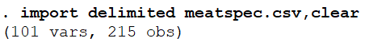

Then we use summarize command to see the brief description of this dataset. Because our dataset has 100 independent variables and 1 dependent variable. We only show the first six of them.

```r
*Summarize Data
summarize v1 v2 v3 v4 v5 fat
```

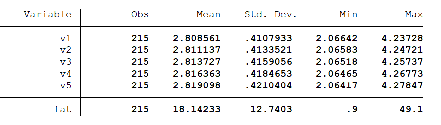

The data seems to be very clean, we just pass to next step.

## Ridge Regression using Package: ridgereg

### Function Description

Because package:ridgereg is not included in Stata, we need to install it first. We will use several options of this function ridgereg: model(orr): ordinary ridge regression.

kr(): ridge $\lambda$ value, it is must be in the range (0 < k < 1).

coll: keep collinear variables; default is removing collinear variables.

diag: Model Selection Diagnostic Criteria; this option returns values of many functions, for example, Log Likelihood Function(LLF) and Akaike Information Criterion(AIC). We will use Craven-Wahba Generalized Cross Validation(GCV) of the regression result for this case.

See references for more information about this package.

```r
*install ridgereg package
ssc install ridgereg
```

### Standardization

As recommanded by the method of ridge regression, we need to standarized our predictors and centered the response first. Using for loop to achieve this object:

```r
*standardize independent variables and centered dependent variable
summarize fat
local mean_fat=r(mean)
replace fat=fat-r(mean)
foreach i of numlist 1/100 {
    summarize v`i'
    replace v`i'=(v`i'-r(mean))/r(sd)
}
```

### $\beta$ridge

As we know from introsuction, the coefficients of ridge regression shrink to 0 with the increasing of $\lambda$ value. If we visualize this process in Stata, we first do ridge regression on each $\lambda$ and then plot coefficients against $\lambda$ value. We could get a plot as below:

```r
*graph of coefficients: converge to 0
preserve
ridgereg fat v* if mod(n,5)!=0,model(orr) kr(0) coll diag
matrix coeff=e(b)
local index=1
generate lambda=0
foreach i of numlist 1e-9(1e-9)5e-8{
    local index=`index'+1
    ridgereg fat v* if mod(n,5)!=0,model(orr) kr(`i') coll diag
    replace lambda=`i' in `index'
    matrix b=e(b)
    matrix coeff=(coeff\b)
}
svmat coeff,names(coeff)
line coeff1-coeff99 lambda
restore
```

**Figure 1.** Coefficients converge to 0 with the increasing of $lambda$

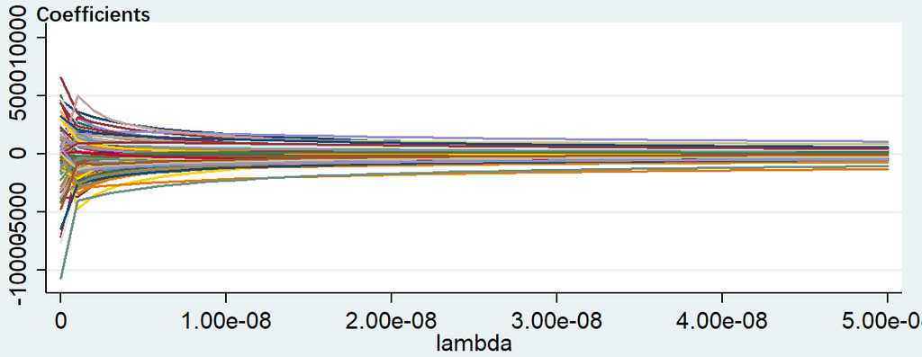

### Selection of $\lambda$

Often there is insufficient data for us to do model assessment. Cross-Validation comes to be a commom solutions for this problem based on predictions. In this way, we set some data aside for test and use the other part do training-validation step. During this process, we choose a series of tuning parameter and do regression on various $\lambda$ values to compare generalized cross-validation estimates. After that, we choose a model which has lowest GCV value and test its performance on prediction.

#### Group

First, we generate a column of case numbers for this dataset.

```r
*cross-validation assign group
generate n=_n
```

In this case, we split our dataset into 5 groups. One of the group is test data, whose case number could be divided by 5 and without reminder. Others are training and validation data.

#### Cross-Validation

In this step, we could simply do training and validation process together based on a model selection diagnostic criteria returned by Stata itself. So, we could save much time. This criteria is generalized cross-validation(GCV) value and it is in ereturn list after doing ridge regression. We just need to choose a $\lambda$ which optimizes this value.

```r
*return GCV(Generalized Cross-Validation) value
generate gcv=10
generate lambda=0
local index=0
foreach i of numlist 0(1e-11)1e-9{
    local index=`index'+1
    ridgereg fat v* if mod(n,5)!=0,model(orr) kr(`i') coll diag
    replace lambda=`i' in `index'
    replace gcv=e(gcv) in `index'
}
```

Then we could plot GCV values against $\lambda$. Soomthing this line.

```r
*graph of GCV values on lamda
lowess gcv lambda if n<=101
```

**Figure 2.** GCV values against different $lambda$

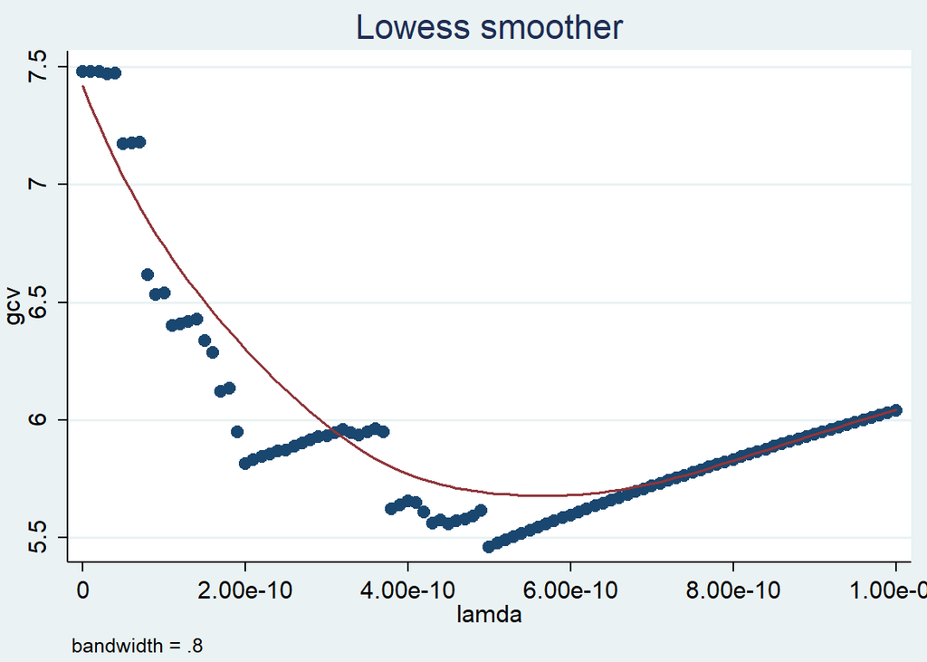

From the plot above, we could see that GCV estimates reaches its minimum around 5e-10. It is the same with the result computed below.

```r
summarize gcv if n<=101
summarize lambda if gcv==r(min)
```

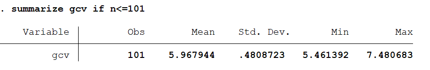

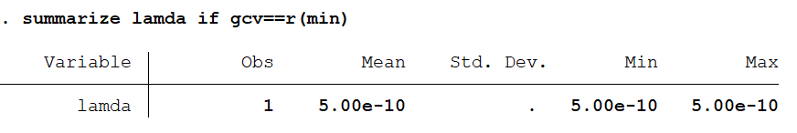

So, we could conclude that $\lambda=5e-10$ for this case.

#### Test model

When come to the last step of model assessment, we try to test the performance of our exisiting model on the test data we keep at first. So, we fit the same model on the same dataset by assigning $\lambda$ and then use matrix manipulation to get predictions. Don’t forget that fat variable is centered at first. We need to add back mean value at last to get preditions of fat on all groups of observations.

```r
*test performances of model, lamda=5e-10
ridgereg fat v* if mod(n,5)!=0,model(orr) kr(5e-10) coll predict(pred)
matrix coeff=e(b)'
generate constant=1
mkmat v* constant, matrix(predictors)
matrix pred_fat=predictors*coeff
svmat pred_fat,names(pred_fat)
```

Finally, MSE of predictions could be computed .Review the formula in introduction to see how it works. Here is the way we could computed in Stata.

```r
*compute MSE
generate err_fat=(pred_fat-fat)^2
summarize err_fat if mod(n,5)==0
display r(mean)
```

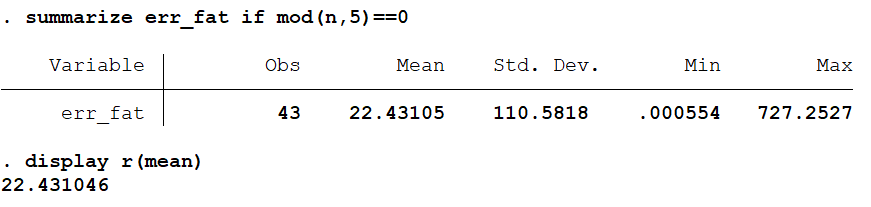

We could see that the MSE of one point even reaches 727. Actually it is an abnormal value. If we exclude this observation, the MSE is much better.

```r
*exclude 727 abnormal observation
summarize err_fat if mod(n,5)==0&n!=185
display r(mean)
```

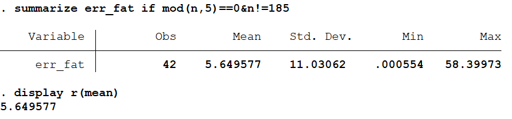

If we use this result to predict, RMSE(Root Mean Sqaured Error), which is the root of MSE, is to be used. RMSE equals 2.377 and it is relatively good.

## Conclusion

As we could see from above, GCV values against $\lambda$ is not continuous. This may bacause predictors are highly correlated and some predictors could not provide extra information for explaining response, so their coefficients are forced to 0. And their coefficients, which equal 0, are not totally the same with the increasing of $\lambda$. In this case, GCV values will have a relative large change compared to last ones. As a result, the graph of GCV values is not strictly continuous. In addition, $\lambda$ is very small after standardization.